# Case study: Partial profiles

Mikkel Meyer Andersen

22 June, 2018

First, the library is loaded:

```r
library(malan)
```

For reproducibility, the seed for the (pseudo) random number generator is set:

```r
set.seed(1)
```

# Population simulation

First, the population sizes are determined:

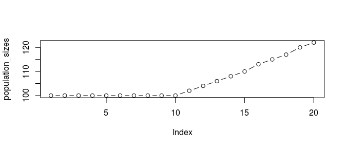

```r
population_sizes <- round(c(rep(100, 10), 100*1.02^(1:10)))
plot(population_sizes, type = "b")
```

A population can be simulated (hiding progress information) as follows:

```r
set.seed(1) # For reproducibility
sim_res_growth <- sample_geneology_varying_size(
  population_sizes = population_sizes,

  # VRS = 0.2:
  enable_gamma_variance_extension = TRUE,
  gamma_parameter_shape = 5,
  gamma_parameter_scale = 1/5,

  # Live population:
  # 3 generations
  generations_full = 3,
  generations_return = 3,

  progress = FALSE)
```

Live population:

```r
live_pop <- sim_res_growth$individuals_generations
```

## Building the pedigrees

Until pedigrees are build/infered, there is not much information available (e.g. about children). So let us infer the pedigrees:

```r
pedigrees <- build_pedigrees(sim_res_growth$population, progress = FALSE)
pedigrees
```

```
## List of 11 pedigrees (of size 109, 94, 90, 87, 83, 70, ...)
```

```r
pedigrees_count(pedigrees)
```

```
## [1] 11
```

```r
pedigrees_table(pedigrees)
```

```
##  18  63  67  70  83  94  90 109  87
##   2   2   1   1   1   1   1   1   1
```

```r
pedigree_size(pedigrees[[1]])
```

```
## [1] 109
```

We can look at the population as a (tidy)graph:

```r
g <- as_tbl_graph(pedigrees)
g
```

```
## # A tbl_graph: 762 nodes and 751 edges
## #
## # A rooted forest with 11 trees
## #
## # Node Data: 762 x 4 (active)
##   name  gens_from_final ped_id haplotype
##   <chr>           <int>  <int> <list>
## 1 756                19      7 <int [0]>
## 2 747                18      7 <int [0]>
## 3 730                17      7 <int [0]>
## 4 725                16      7 <int [0]>
## 5 712                15      7 <int [0]>
## 6 695                14      7 <int [0]>
## # ... with 756 more rows
## #
## # Edge Data: 751 x 2
##    from    to
##   <int> <int>
## 1     1     2
## 2     2     3
## 3     3     4
## # ... with 748 more rows
```

This can be plotted:

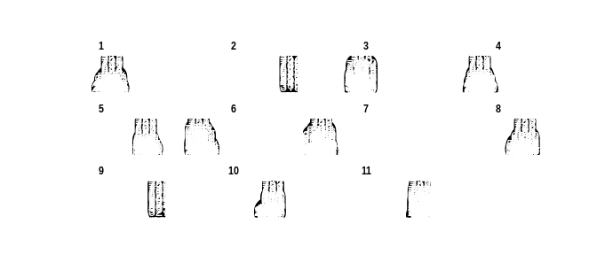

```r
if (requireNamespace("ggraph", quietly = TRUE)) {
  library(ggraph)
  p <- ggraph(g, layout = 'tree') +
    geom_edge_link() +
    geom_node_point(size = 8) +
    geom_node_text(aes(label = name), color = "white") +
    facet_nodes(~ ped_id) +
    theme_graph()

  print(p)
}
```

This is rather difficult to make any sense of. Let’s instead plot only pedigree 1:

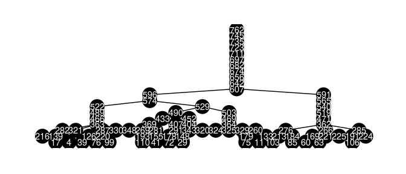

```r
PED_ID <- 1

g_ped2 <- g %>%
  activate(nodes) %>%
  filter(ped_id == PED_ID)

if (requireNamespace("ggraph", quietly = TRUE)) {
  library(ggraph)
  p <- ggraph(g_ped2, layout = 'tree') +
      geom_edge_link() +
      geom_node_point(size = 8) +
      geom_node_text(aes(label = name), color = "white") +
      theme_graph()
  print(p)
}
```

## Run a mutation process

Up until now, only the genealogy has been simulated. Now, we run a mutational process, i.e. assign haplotypes to founders and let haplotypes flow down the individuals.

We use realistic data. In the package, there is information about the individual markers:

```r
ystr_markers
```

```
## # A tibble: 29 x 5
##    Marker  Mutations Meioses  MutProb Alleles
##    <fct>       <dbl>   <dbl>    <dbl> <list>
##  1 DYS438          4   10673 0.000375 <dbl [22]>
##  2 DYS392          8   15418 0.000519 <dbl [22]>
##  3 DYS393         15   14264 0.00105  <dbl [17]>
##  4 DYS437         13   10652 0.00122  <dbl [15]>
##  5 DYS385a        32   26171 0.00122  <dbl [52]>
##  6 DYS385b        32   26171 0.00122  <dbl [52]>
##  7 DYS643          3    2220 0.00135  <dbl [17]>
##  8 DYS448         11    7229 0.00152  <dbl [36]>
##  9 DYS390         33   15612 0.00211  <dbl [19]>
## 10 DYS19          36   16090 0.00224  <dbl [19]>
## # ... with 19 more rows
```

Note, that `MutProb` is the point estimate given by `MutProb = Mutations / Meioses`. Information about which markers that are in which kit is also provided:

```r
ystr_kits
```

```
## # A tibble: 88 x 2
##    Marker   Kit
##    <fct>    <fct>
##  1 DYS392   Minimal
##  2 DYS393   Minimal
##  3 DYS385a  Minimal
##  4 DYS385b  Minimal
##  5 DYS390   Minimal
##  6 DYS19    Minimal
##  7 DYS391   Minimal
##  8 DYS389I  Minimal
##  9 DYS389II Minimal
## 10 DYS438   PowerPlex Y
## # ... with 78 more rows
```

```r
ystr_kits %>% count(Kit)
```

```
## # A tibble: 5 x 2
##   Kit               n
##   <fct>         <int>
## 1 Minimal           9
## 2 PowerPlex Y      12
## 3 Yfiler           17
## 4 PowerPlex Y23    23
## 5 Yfiler Plus      27
```

Let us take all PowerPlex Y23 markers and assume that we only have a partial profile where `DYS437` and `DYS448` dropped out. At the same time, we also filter out the integer alleles (for generating random founder haplotypes in a minute):

```r
partial_kit <- ystr_kits %>%
  filter(Kit == "PowerPlex Y23") %>%
  inner_join(ystr_markers, by = "Marker") %>%
  filter(!(Marker %in% c("DYS437", "DYS448"))) %>%
  rowwise() %>% # To work on each row
  mutate(IntegerAlleles = list(Alleles[Alleles == round(Alleles)]),
         MinIntAllele = min(IntegerAlleles),
         MaxIntAllele = max(IntegerAlleles)) %>%
  ungroup() %>%
  select(-Kit, -Alleles)
partial_kit
```

```
## # A tibble: 21 x 7
##    Marker  Mutations Meioses  MutProb IntegerAlleles MinIntAllele
##    <fct>       <dbl>   <dbl>    <dbl> <list>                <dbl>
##  1 DYS438          4   10673 0.000375 <dbl [14]>                5
##  2 DYS392          8   15418 0.000519 <dbl [14]>                6
##  3 DYS393         15   14264 0.00105  <dbl [12]>                7
##  4 DYS385a        32   26171 0.00122  <dbl [23]>                6
##  5 DYS385b        32   26171 0.00122  <dbl [23]>                6
##  6 DYS643          3    2220 0.00135  <dbl [13]>                4
##  7 DYS390         33   15612 0.00211  <dbl [14]>               17
##  8 DYS19          36   16090 0.00224  <dbl [12]>                9
##  9 DYS391         38   15486 0.00245  <dbl [12]>                5
## 10 DYS389I        42   14339 0.00293  <dbl [9]>                 9
## # ... with 11 more rows, and 1 more variable: MaxIntAllele <dbl>
```

This “partial kit” has the following mutation probabilities:

```r
mu <- partial_kit %>% pull(MutProb)
mu
```

```
##  [1] 0.0003747775 0.0005188740 0.0010515984 0.0012227274 0.0012227274
##  [6] 0.0013513514 0.0021137586 0.0022374145 0.0024538293 0.0029290746
## [11] 0.0030266344 0.0036747818 0.0037541061 0.0041229909 0.0042882833
## [16] 0.0043338286 0.0050205386 0.0054475439 0.0063641395 0.0133475707
## [21] 0.0147194112
```

We can make a founder haplotype generator as follows (sampling alleles randomly is not how Y-STR works, but it may work fine for founder haplotypes):

```r
generate_random_haplotype <- function() {
  partial_kit %>%
    rowwise() %>%
    mutate(Allele = IntegerAlleles[sample.int(length(IntegerAlleles), 1)]) %>%
    pull(Allele)
}
```

Now, a new haplotype is created everytime the function is called (with no arguments):

```r
generate_random_haplotype()
```

```
##  [1] 11 16 17 18 13 10 17 11 12 13  9 11 10 28 15 22 18 14 16 20 14
```

```r
generate_random_haplotype()
```

```
##  [1] 14 11  8 12 21  9 21 12  8 17  9 13 14 31 13 30 20  7 15 22 25
```

Of course such generator can also be created for a reference database with Y-STR profiles.

Now, we are ready to assign haplotypes to the genealogy:

```r
set.seed(1)
pedigrees_all_populate_haplotypes_custom_founders(
  pedigrees = pedigrees,
  get_founder_haplotype = generate_random_haplotype,
  mutation_rates = mu,
  progress = FALSE)
```

We can now plot pedigrees with haplotype information (note that `as_tbl_graph` needs to be called again):

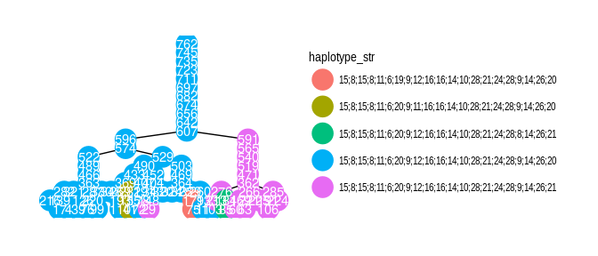

```r
g_ped2 <- as_tbl_graph(pedigrees) %>%
  activate(nodes) %>%
  filter(ped_id == PED_ID) %>%
  group_by(name) %>%
  mutate(haplotype_str = paste0(haplotype[[1]], collapse = ";"))
  #mutate(haplotype_str = map(haplotype, paste0, collapse = ";")[[1]])

if (requireNamespace("ggraph", quietly = TRUE)) {
  library(ggraph)
  p <- ggraph(g_ped2, layout = 'tree') +
      geom_edge_link() +
      geom_node_point(aes(color = haplotype_str), size = 8) +
      geom_node_text(aes(label = name), color = "white") +
      theme_graph()
  print(p)
}
```

# Counting matches

We have `live_pop` from the population.

## Drawing an individual and counting matches

```r
set.seed(5)
Q_index <- sample.int(n = length(live_pop), size = 1)
Q <- live_pop[[Q_index]]
print_individual(Q)
```

```
##   pid = 72 with father pid = 178 and no children
```

```r
Q_hap <- get_haplotype(Q)
Q_hap
```

```
##  [1] 15  8 15  8 11  6 20  9 12 16 16 14 10 28 21 24 28  9 14 26 20
```

Now, count matches in live part of pedigree and in live part of population:

```r
Q_ped <- get_pedigree_from_individual(Q)
ped_live_matches <- count_haplotype_occurrences_pedigree(
  pedigree = Q_ped,
  haplotype = Q_hap,
  generation_upper_bound_in_result = 2) # gen 0, 1, 2
pop_live_matches <- count_haplotype_occurrences_individuals(
  individuals = live_pop,
  haplotype = Q_hap)

ped_live_matches
```

```
## [1] 30
```

```r
pop_live_matches
```

```
## [1] 30
```

We can also inspect pedigree matches information about number of meioses and $L_1$ distances:

```r
path_details <- pedigree_haplotype_matches_in_pedigree_meiosis_L1_dists(
  suspect = Q,
  generation_upper_bound_in_result = 2)
```

```r
nrow(path_details)
```

```
## [1] 30
```

```r
head(path_details)
```

```
##      meioses max_L1 pid
## [1,]      12      0 282
## [2,]      13      0 216
## [3,]      13      0 139
## [4,]      14      0  17
## [5,]      13      0 126
## [6,]      14      0   4
```

This can of course be repeated to many populations (genealogies, haplotype processes, suspects etc.). Also note that variability can be put on mutation rates, e.g. by a Bayesian approach.